# Подготовка экспериментального стенда GNS3

Лабораторная работа №4

Гафоров Нурмухаммад

Российский университет дружбы народов, Москва, Россия

20 октября 2025

# Цели и задачи работы

## Цель лабораторной работы

Установить и настроить среду **GNS3** и виртуальные образы маршрутизаторов для моделирования сетевой инфраструктуры.

# Ход выполнения

## Запуск виртуальной машины GNS3

Была запущена виртуальная машина **GNS3 VM**, после чего открыто приложение **GNS3**.  
При первом запуске выбран режим работы *Run appliances in a virtual machine*.

[figure not shown]

## Настройка подключения контроллера

В мастере настройки указаны параметры подключения:  
- **Protocol:** HTTP  
- **Host:** 192.168.133.131  
- **Port:** 80  
- **Username:** admin

После подтверждения соединение установлено успешно.

[figure not shown]

## Добавление образа FRR

Через меню `New template` выбран маршрутизатор **FRR (FRRouting Project)**.  
В процессе установки использован образ `frr-8.2.2.qcow2`.

[figure not shown]

Выбор образа FRR

## Параметры шаблона FRR

Настроены параметры виртуальной машины:  
- **RAM:** 256 MB  
- **vCPUs:** 1  
- **Console type:** telnet  
- **On close:** Send the shutdown signal (ACPI)

[figure not shown]

Основные настройки FRR

## Настройка виртуального диска FRR

Активирована опция *Automatically create a config disk on HDD*, обеспечивающая сохранение конфигурации устройства.

[figure not shown]

Настройки диска FRR

## Проверка запуска FRR

После установки выполнен запуск устройства, в консоли **PuTTY** отображается баннер **FRRouting 8.2.2**, что подтверждает успешную загрузку.

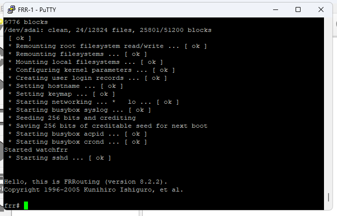

Запуск маршрутизатора FRR

## Добавление образа VyOS

Аналогичным образом добавлен образ маршрутизатора **VyOS**.  
Выбрана версия `VyOS 1.3.3-qemu`.

[figure not shown]

Выбор версии VyOS

## Проверка запуска VyOS

После установки в консоли **PuTTY** появился приветственный экран **VyOS**, подтверждающий корректную инициализацию системы.

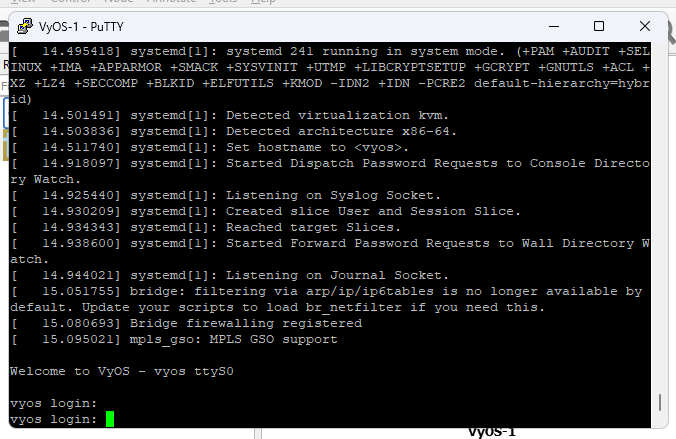

Запуск маршрутизатора VyOS

# Выводы

## Итог лабораторной работы

В ходе работы были установлены и настроены образы маршрутизаторов **FRR** и **VyOS** в среде **GNS3**.  
Оба устройства успешно запущены, что подтверждает готовность виртуальной лабораторной среды для дальнейшего моделирования сетевых топологий.